# Bike Share Data Analysis

Michael Tabb

2025-09-17

Introduction For this project, I analyzed bikeshare data from Chicago, New York City, and Washington. The goal was to answer four main questions:

What is the most popular day of the week in each city?

What is the average trip duration by user type and city?

What are the most common start stations in each city?

What are the peak hours of usage by city?

Data Preparation I created a reusable function called load_city_data() to load and clean the data for each city. Then I combined all three datasets into one dataframe.

```r
# Function to load and clean data
load_city_data <- function(file_path, city_name) {
  data <- read_csv(file_path) %>%
    mutate(
      Start_Time_Parsed = parse_date_time(`Start Time`,
                                          orders = c("Ymd HMS", "Y-m-d H:M:S",
                                                     "m/d/Y H:M", "m/d/Y H:M:S")),
      City = city_name
    ) %>%
    filter(!is.na(Start_Time_Parsed)) %>%
    mutate(
      Day_of_Week = wday(Start_Time_Parsed, label = TRUE, abbr = TRUE),
      Hour = hour(Start_Time_Parsed)
    )
  return(data)
}

# Dictionary of cities and file paths
cities <- list(
  Chicago = "chicago.csv",
  "New York City" = "new-york-city.csv",
  Washington = "washington.csv"
)

# Load all datasets together
bike_data <- map2_dfr(cities, names(cities), load_city_data)
```

Question 1: Most Popular Day of the Week

```r
popular_day <- bike_data %>%
  group_by(City, Day_of_Week) %>%
  summarise(Trips = n(), .groups = "drop") %>%
  arrange(City, desc(Trips))

# Most popular day per city
popular_day %>%
  group_by(City) %>%
  slice_max(Trips, n = 1)
```

```
## # A tibble: 3 × 3
## # Groups:   City [3]
##   City          Day_of_Week Trips
##   <chr>         <ord>       <int>
## 1 Chicago       Tue         45912
## 2 New York City Wed         52087
## 3 Washington    Wed         48154
```

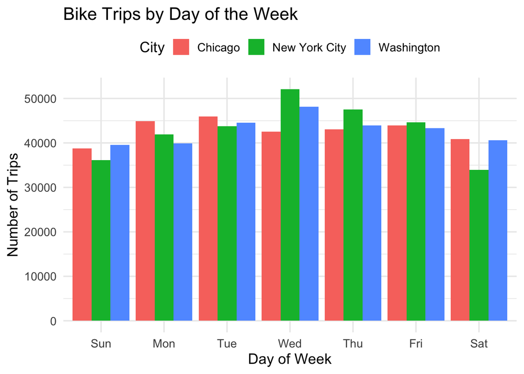

```r
# Plot
ggplot(popular_day, aes(x = Day_of_Week, y = Trips, fill = City)) +
  geom_col(position = "dodge") +
  labs(title = "Bike Trips by Day of the Week",
       x = "Day of Week",
       y = "Number of Trips") +
  theme_minimal(base_size = 14) +
  theme(legend.position = "top")
```

Question 2: Average Trip Duration by User Type

```r
avg_duration_user_type <- bike_data %>%
  filter(!is.na(`User Type`), !is.na(`Trip Duration`)) %>%
  group_by(City, `User Type`) %>%
  summarise(Average_Duration = mean(`Trip Duration`, na.rm = TRUE),
            Median_Duration = median(`Trip Duration`, na.rm = TRUE),
            .groups = "drop")

avg_duration_user_type
```

```
## # A tibble: 7 × 4
##   City          `User Type` Average_Duration Median_Duration
##   <chr>         <chr>                  <dbl>           <dbl>
## 1 Chicago       Customer               1863.           1380
## 2 Chicago       Dependent               311             311
## 3 Chicago       Subscriber              699.            565
## 4 New York City Customer               2056.           1304
## 5 New York City Subscriber              769.            564
## 6 Washington    Customer               2635.           1492.
## 7 Washington    Subscriber              736.            570.
```

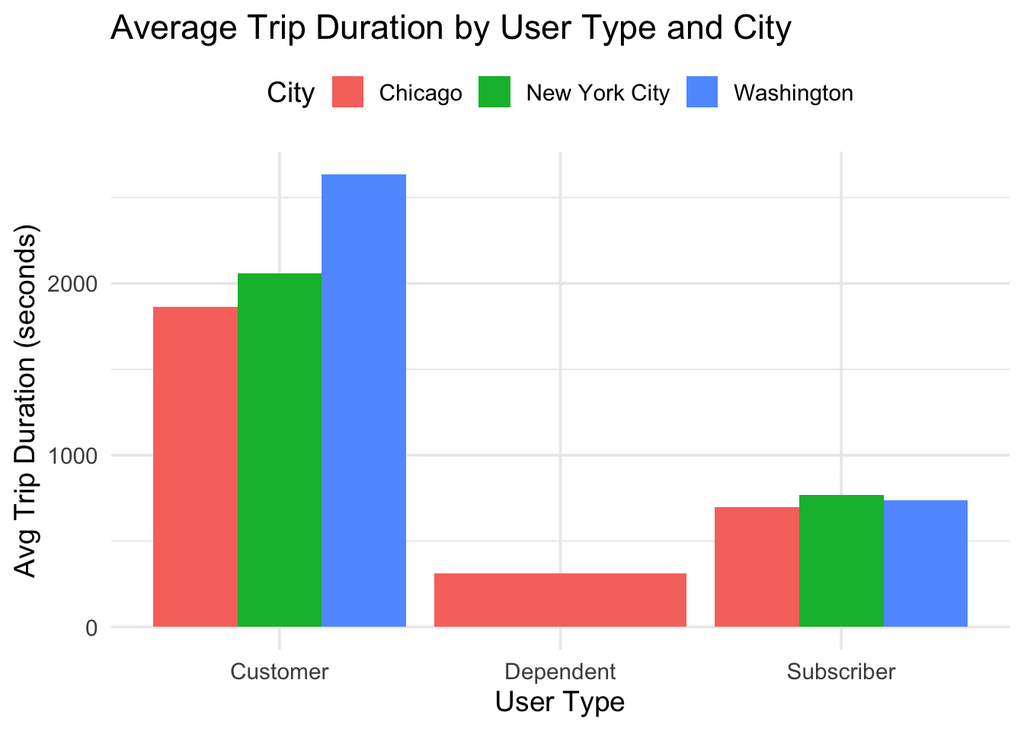

```r
# Plot
ggplot(avg_duration_user_type, aes(x = `User Type`, y = Average_Duration, fill = City)) +
  geom_col(position = "dodge") +
  labs(title = "Average Trip Duration by User Type and City",
       x = "User Type",
       y = "Avg Trip Duration (seconds)") +
  theme_minimal(base_size = 14) +
  theme(legend.position = "top")
```

Subscribers typically have shorter trips (often commuting), while casual users take longer trips on average.

Question 3: Most Common Start Stations

```r
top_start_stations <- bike_data %>%
  group_by(City, `Start Station`) %>%
  summarise(Trips = n(), .groups = "drop") %>%
  arrange(City, desc(Trips)) %>%
  group_by(City) %>%
  slice_head(n = 1)

top_start_stations
```

```
## # A tibble: 3 × 3
## # Groups:   City [3]
##   City          `Start Station`                 Trips
##   <chr>         <chr>                           <int>
## 1 Chicago       Streeter Dr & Grand Ave          6911
## 2 New York City Pershing Square North            3069
## 3 Washington    Columbus Circle / Union Station  5656
```

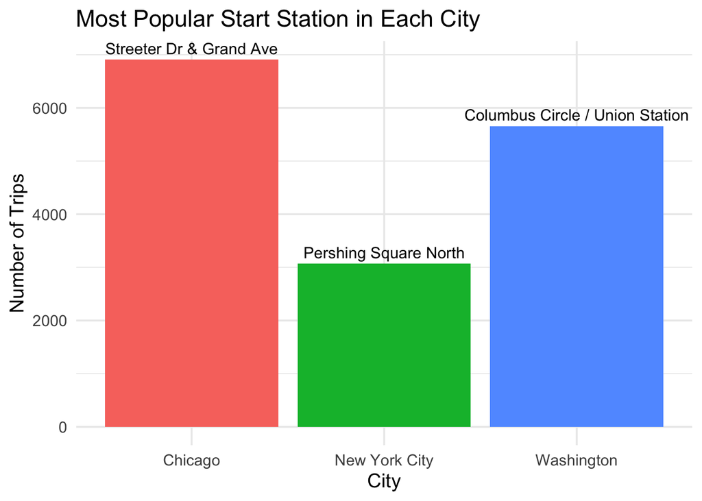

```r
# Plot
ggplot(top_start_stations, aes(x = City, y = Trips, fill = City)) +
  geom_col() +
  geom_text(aes(label = `Start Station`), vjust = -0.5, size = 4) +
  labs(title = "Most Popular Start Station in Each City",
       x = "City",
       y = "Number of Trips") +
  theme_minimal(base_size = 14) +
  theme(legend.position = "none")
```

Each city has a standout station that accounts for a large number of trips, often near central hubs or attractions.

Question 4: Peak Hours of Usage

```r
peak_hours <- bike_data %>%
  filter(!is.na(Hour)) %>%
  group_by(City, Hour) %>%
  summarise(Trips = n(), .groups = "drop") %>%
  group_by(City) %>%
  mutate(Percent = Trips / sum(Trips) * 100)

peak_hours
```

```
## # A tibble: 72 × 4
## # Groups:   City [3]
##    City     Hour Trips Percent
##    <chr>   <int> <int>   <dbl>
##  1 Chicago     0  1684   0.561
##  2 Chicago     1   982   0.327
##  3 Chicago     2   609   0.203
##  4 Chicago     3   372   0.124
##  5 Chicago     4   467   0.156
##  6 Chicago     5  2437   0.812
##  7 Chicago     6  8246   2.75
##  8 Chicago     7 18380   6.13
##  9 Chicago     8 24134   8.04
## 10 Chicago     9 13691   4.56
## # ℹ 62 more rows
```

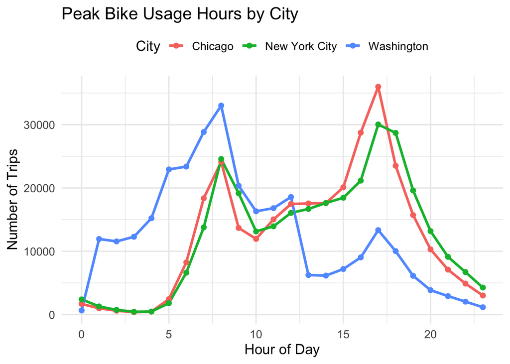

```r
# Plot
ggplot(peak_hours, aes(x = Hour, y = Trips, color = City)) +
  geom_line(size = 1.2) +
  geom_point() +
  labs(title = "Peak Bike Usage Hours by City",
       x = "Hour of Day",
       y = "Number of Trips") +
  theme_minimal(base_size = 14) +
  theme(legend.position = "top")
```

Usage peaks during commute hours (around 8 AM and 5–6 PM), showing that many riders use bikeshare for work commutes. Conclusion

Trip Durations: Subscribers ride shorter trips, while casual users ride longer.

Start Stations: Popular start stations are near central hubs or attractions.

Peak Hours: Morning and evening commutes dominate bike usage.

This analysis highlights how bikeshare usage varies across cities and reflects both commuter and recreational behavior.